# Population Graphs On Contigs I: Sampling Intensity & Topological Convergence

With the ever increasing use of sequencing in the analysis of both neutral and putatively adaptive genetic variance the ability to recover genetic covartiance becomes increasinly difficult as the density of information rich genetic markers incereases. In this manuscript, we examine the extent to which population genetic structure, as measured through population graphs, is influenced by locus proximity.

Rodney J. Dyer https://dyerlab.org (Center for Environmental Studies  
Virginia Commonwealth University  
)https://ces.vcu.edu  
2022-07-01

Are there metrics that can be used to define topological and structural similarity in one or more population graphs?

# Methods

## Graph Theoretic Definitions

A graph contains two sets of objects, *nodes* often representing sampling locales, populations, or regions, and *edges* which specify the relationships between individual nodes. In population genetic studies, graphs are often defined based upon pair-wise genetic distances (Nei’s Distance, $D_{ps}$, etc.) or estimates of structure (pairwise $F_{ST}$, cGD, etc).

For the purposes of this paper, genetic topologies will be created using conditional genetic distance (cGD) found within Population Graph R. J. Dyer (2015)

## The Data

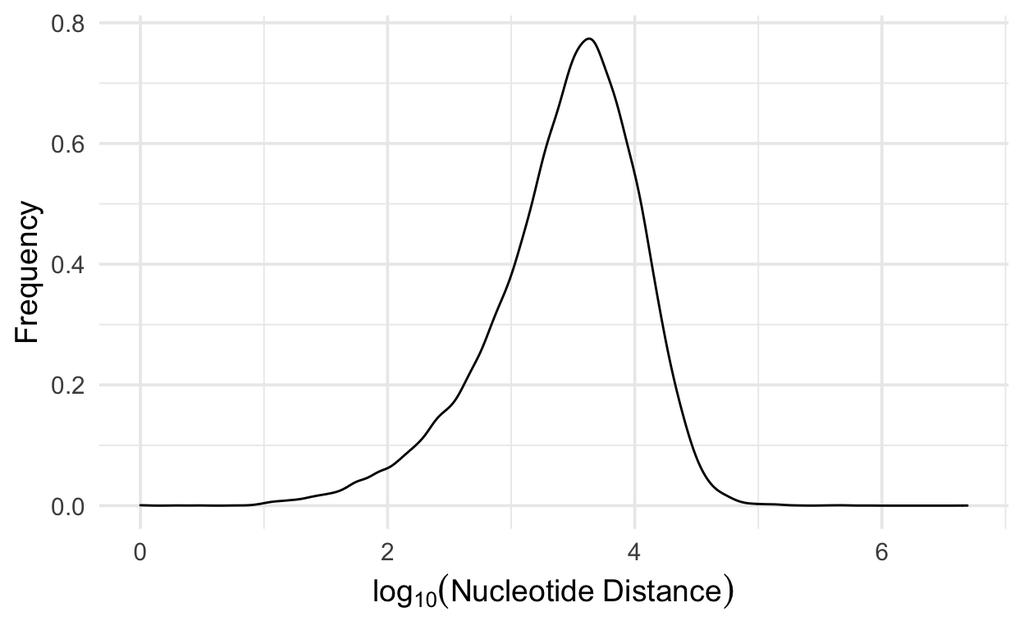

Figure 1: The distribution of nearest neighbor distances for individual SNPs along Chromosome 2

## Topological Similarity

As a first pass, one can consider the similarity of two graphs. For example, consider the graphs $G$ and $H$, both of which have identical node sets (e.g., the two graphs have the same cardinality in that $V(G) = V(H)$). For most purposes here, we will only be considering comparisons of graphs that have the identical set of nodes as we are looking at population-level genetic covariance among the same set of populations only with different sets of genetic markers.

In this context, any pair of population graphs are said to be *graph-level isomorphic* if and only if the exact same set of edges in popgraph $G$ are present in other popgraph $H$. For this paper, I will refer to this a *structural congruence* to designate that it is the set of similar edges in the two networks that are the focus of the question.

In addition to structural congruence, population graphs may be similar because they have a similar configuration of the overall distances between sampling locals, independent of the sequence of edges through which they traverse. This is the most commonly used approach as we typically estimate the measure of distance between sites from the genetic data and relate that to some measure of separation caused by space, ecology, vicariance, etc. The distinction here is that the actual path, and by extension the individual connections between sampling locales, are not the focus of the question, only the cumulative distance between nodes.

### Structural Congruence

For questions regarding the arrangement of connections between specific nodes in the topology. The likelihood that two graphs with isomorphic node sets (say of size $K$), $A$ and $B$, have $m$ edges in common can be determined combinatorially with the following definitions. Let $m_A$ be the number of edges in $A$, $m_B$ be the number of edges in graph $B$, and $m_C$ be the number of edges in the congruence topology derived from both $A$ and $B$. The maximum number of potential edges (and hence the ceiling for $m_C$) is $m_{max} = K * (K-1) / 2$.

### Sampling Intensity

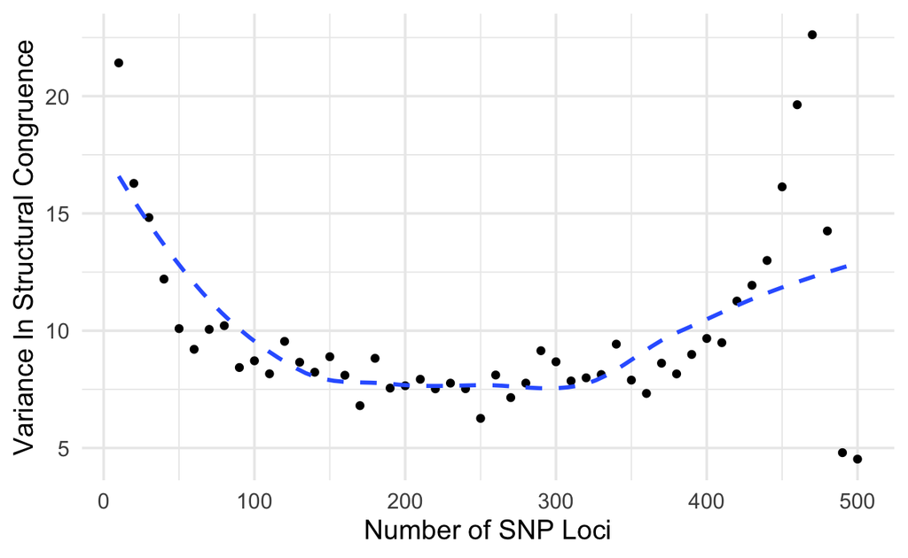

*Distance Congruence*

For questions and hypotheses regarding the relative genetic distances between locales as is common in studies of isolation by distance, resistance, and ecology.

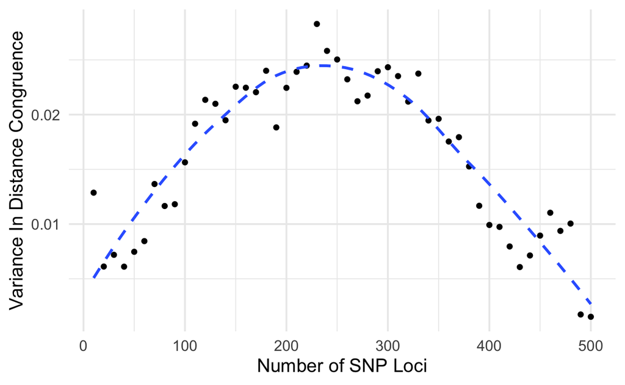

### Window Sampling

*Structural Congruence*

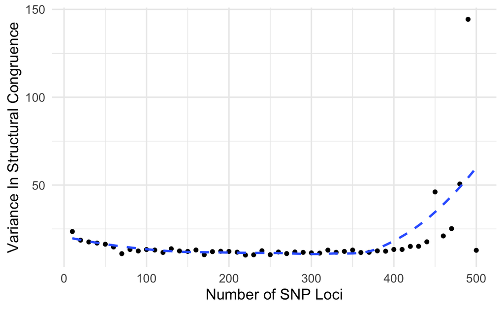

*Distance Congruence*

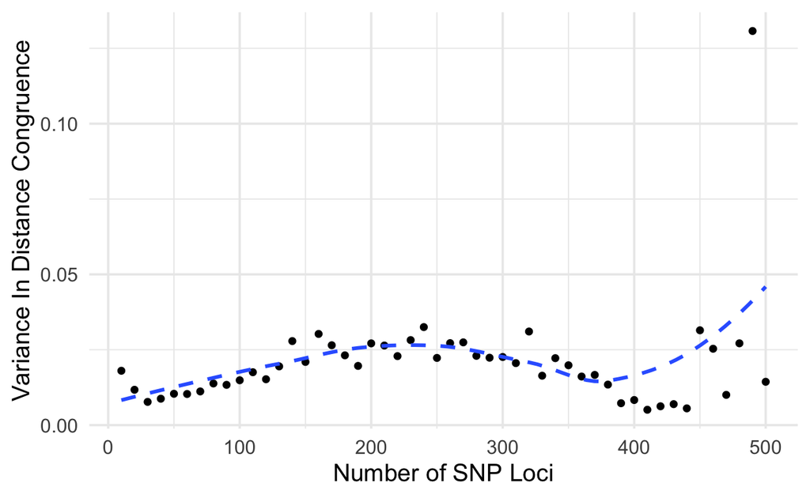

## Disconnected Subgraphs

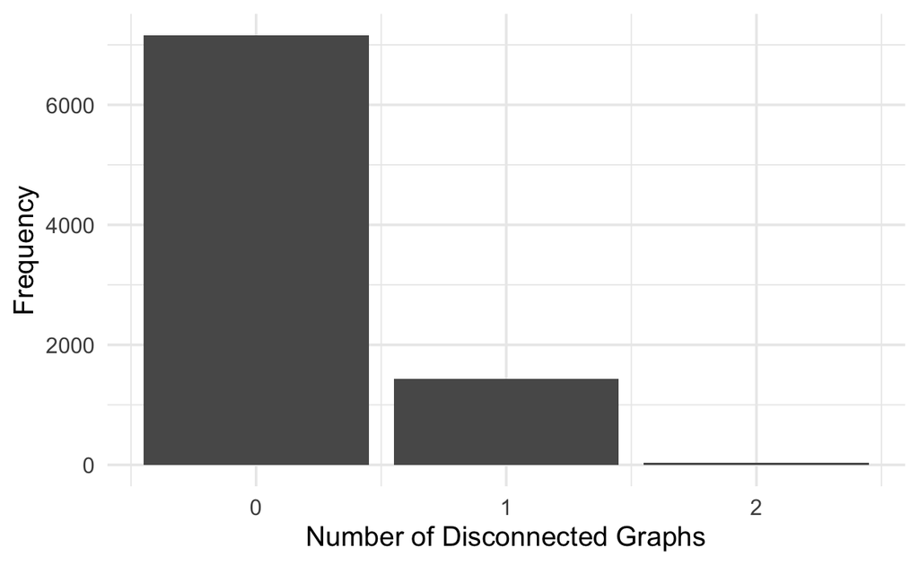

## Locus Sensitivity Analysis

There are a couple of features of topology that we should examine to evaluate potential bias in sampling.

Eigenvalue Sensitivity

A population graph can be represented as a square matrix ($\mathbf{A}$ of size $k$x$k$), whose elements, $a_{ij}$ represent the conditional genetic distance between the $i^{th}$ and $j^{th}$ for those that have a direct connection and $a_{ij} = 0$ for those who are not directly connected in the toplogy.

For adjacency matrices such as we find in Population Graphs, whose edges are bi-directional as they are defined upon genetic covariance and who have no self loops, there is a well defined structure to the an eigendecomposition.

$$Aw_i = \lambda_i w_i \\
v_i^TA = \lambda_i v_i^T$$

We can decompose the matrix $\mathbf{A}$ into a sequence of $K$ additive parts such that

$$\mathbf{A} = \sum_{i=1}^K \lambda_i \vec{v}_i \vec{v}_i^T$$

where $\lambda$ is a scaling factor called an *eigvenvalue* (and for convienence they are ordered from largest to smallest) and an associated $\vec{v}_i$ that specify the a rotation in $k-$space associated with the value (and known as a *eigenvector*).

The Laplacian of a graph is defined as the square matrix $\mathbf{L}$ whose elements are:

$$L =\left\{\begin{array}{cl}
deg(i), & \mbox{if}\;i=j\\
-1, & \mbox{if}\; (i,j) \in E\\
0, & \mbox{elsewhere}
\end{array}\right.$$

$$det(A-\lambda I) = 0$$

```
     [,1] [,2] [,3] [,4]
[1,]    0    1    1    0
[2,]    1    0    1    0
[3,]    1    1    0    1
[4,]    0    0    1    0
```

```
IGRAPH 2ec9bc1 U--- 4 4 --
+ edges from 2ec9bc1:
[1] 1--2 1--3 2--3 3--4
```

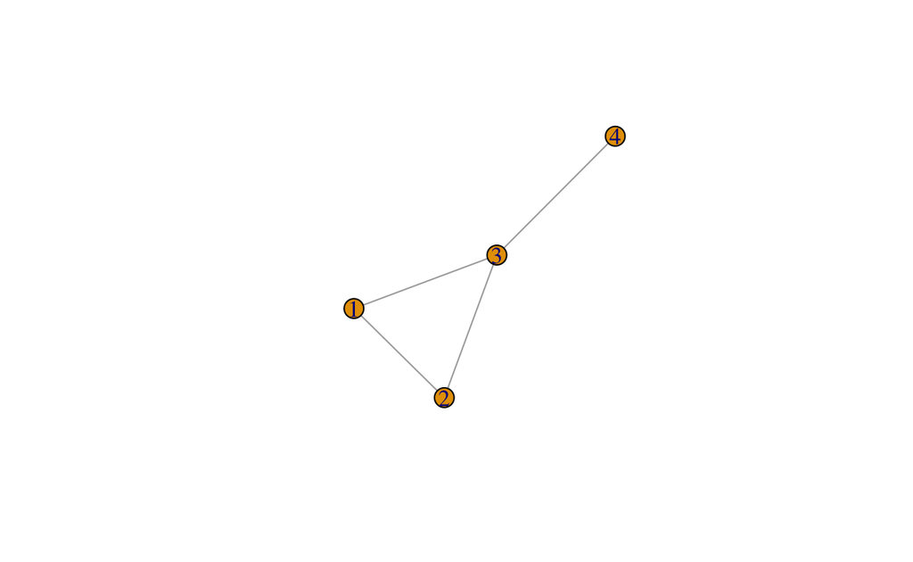

```
4 x 4 sparse Matrix of class "dgCMatrix"

[1,]  2 -1 -1  .
[2,] -1  2 -1  .
[3,] -1 -1  3 -1
[4,]  .  . -1  1
```

```
     [,1] [,2] [,3] [,4]
[1,]    0    2    6    0
[2,]    2    0    7    0
[3,]    6    7    0   15
[4,]    0    0   15    0
```

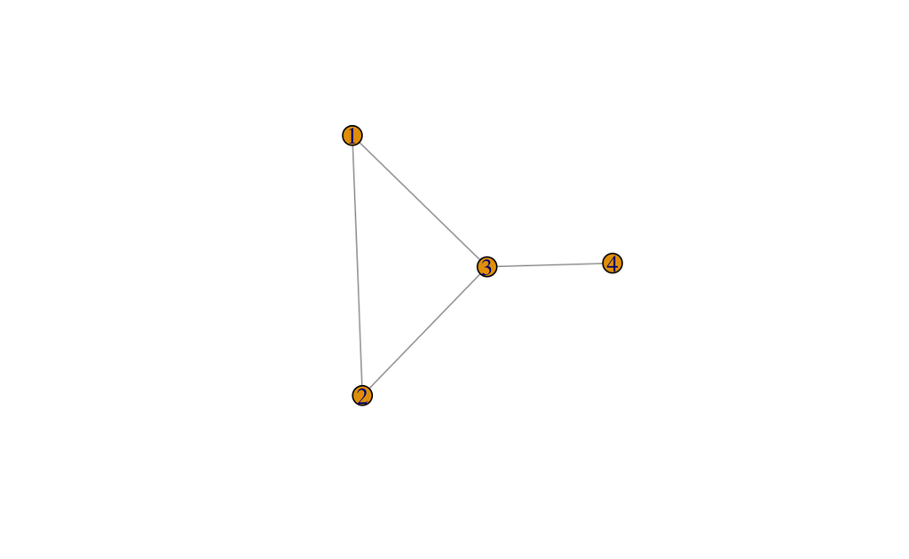

```
4 x 4 sparse Matrix of class "dgCMatrix"

[1,]  8 -2  -6   .
[2,] -2  9  -7   .
[3,] -6 -7  28 -15
[4,]  .  . -15  15
```

$$L_w =\left\{\begin{array}{cl}
\sum_{j=1}^Kw_j, & \mbox{if}\;i=j\\
-w_{ij}, & \mbox{if}\; (i,j) \in E\\
0, & \mbox{elsewhere}
\end{array}\right.$$

One of the properties of this matrix is that for any real number vector, $\vec{v}$, that is of the same length as the number of nodes in $G$, the polynomial $\vec{v}^tL\vec{v}$ produces the sum of squares of the lengths of all the edges in the graph ($(i,j) \in E$).

$$\begin{align}
\vec{v}^tL\vec{v} & = \sum_{i=1}^K v_i \sum_{j: (i,j) \in E} (v_i -
v_j) \\
& = \sum_{(i,j) \in E} v_i (v_i - v_j) \\
& = \sum_{i<j:(i,j) \in E} v_i( v_i - v_j) + v_j(v_j - v_i) \\
& = \sum_{i<j:(i,j) \in E} (v_i - v_j)^2
\end{align}$$

# Discussion

# Acknowledgements

Dyer, R. J. 2015. *Landscapes and Plant Population Genetics*. *Landscape Genetics: Concepts, Methods, Applications*. https://doi.org/10.1002/9781118525258.ch11.

Dyer, Rodney J, and John D Nason. 2004. “Population Graphs: The Graph Theoretic Shape of Genetic Structure.” *Molecular Ecology* 13: 1713–27. http://www.ncbi.nlm.nih.gov/pubmed/15189198.